# Do Certain Factors Contribute to Better/Worse Sleep Quality?

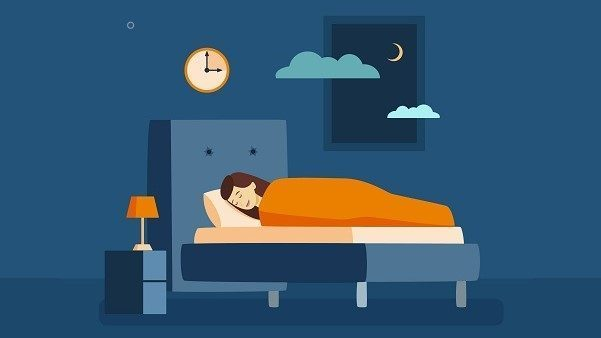

### Eileen Vincent Bose

December 03, 2023

## Background and Motivation

The importance of getting a good night's rest often goes unnoticed in the fast-paced world we live in today where technological advancements and career driven demands continue to rise. Sleep is a fundamental aspect of human health, playing an essential role in the physical, mental, and emotional well-being of a human. For this project, I wanted to see if there were any factors that impact sleep quality. More specifically, I wanted to see whether certain factors such as the daily steps a person takes, stress level, or occupation have a significant correlation with the quality of sleep. The motivation for this topic lies behind the amouont of sleep I have gotten over the past few months at night on an average. I was curious to see whether certain factors contribute to better/worse sleep quality.

## Methodology

I first imported all the necessary modules and loaded the dataset.

```python
# import statements
import pandas as pd
import matplotlib.pyplot as plt
import numpy as np
from matplotlib import style

# open the dataset using pandas read_csv
sleep_data = pd.read_csv('Sleep_Health_and_lifestyle_dataset.csv')
sleep_data
```

|  | Person ID | Gender | Age | Occupation | Sleep Duration | Quality of Sleep | Physical Activity Level | Stress Level | BMI Category | Blood Pressure | Heart Rate | Daily Steps | Sleep Disorder |
| --- | --- | --- | --- | --- | --- | --- | --- | --- | --- | --- | --- | --- | --- |
| 0 | 1 | Male | 27 | Software Engineer | 6.1 | 6 | 42 | 6 | Overweight | 126/83 | 77 | 4200 | None |
| 1 | 2 | Male | 28 | Doctor | 6.2 | 6 | 60 | 8 | Normal | 125/80 | 75 | 10000 | None |
| 2 | 3 | Male | 28 | Doctor | 6.2 | 6 | 60 | 8 | Normal | 125/80 | 75 | 10000 | None |
| 3 | 4 | Male | 28 | Sales Representative | 5.9 | 4 | 30 | 8 | Obese | 140/90 | 85 | 3000 | Sleep Apnea |
| 4 | 5 | Male | 28 | Sales Representative | 5.9 | 4 | 30 | 8 | Obese | 140/90 | 85 | 3000 | Sleep Apnea |
| ... | ... | ... | ... | ... | ... | ... | ... | ... | ... | ... | ... | ... | ... |
| 369 | 370 | Female | 59 | Nurse | 8.1 | 9 | 75 | 3 | Overweight | 140/95 | 68 | 7000 | Sleep Apnea |
| 370 | 371 | Female | 59 | Nurse | 8.0 | 9 | 75 | 3 | Overweight | 140/95 | 68 | 7000 | Sleep Apnea |
| 371 | 372 | Female | 59 | Nurse | 8.1 | 9 | 75 | 3 | Overweight | 140/95 | 68 | 7000 | Sleep Apnea |
| 372 | 373 | Female | 59 | Nurse | 8.1 | 9 | 75 | 3 | Overweight | 140/95 | 68 | 7000 | Sleep Apnea |
| 373 | 374 | Female | 59 | Nurse | 8.1 | 9 | 75 | 3 | Overweight | 140/95 | 68 | 7000 | Sleep Apnea |

374 rows × 13 columns

I used indexing to just focus on the quality of sleep.

```python
quality_sleep = sleep_data['Quality of Sleep']
quality_sleep
```

```
0      6
1      6
2      6
3      4
4      4
      ..
369    9
370    9
371    9
372    9
373    9
Name: Quality of Sleep, Length: 374, dtype: int64
```

I filtered out my data to get the necessary columns.

```python
daily_steps = sleep_data['Daily Steps']
daily_steps
```

```
0       4200
1      10000
2      10000
3       3000
4       3000
       ...
369     7000
370     7000
371     7000
372     7000
373     7000
Name: Daily Steps, Length: 374, dtype: int64
```

I plotted the daily steps and quality of sleep using a scatterplot as both included numbers. I wanted to see if there was any correlation.

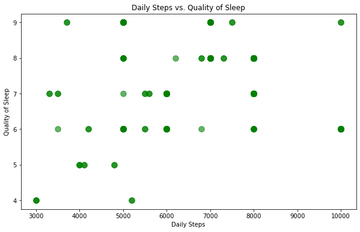

```python
import numpy as np
import matplotlib.pyplot as plt
plt.scatter(daily_steps, quality_sleep, alpha=0.6, color='green', s=90)

plt.title("Daily Steps vs. Quality of Sleep")
plt.xlabel("Daily Steps")
plt.ylabel("Quality of Sleep")
plt.rcParams['figure.figsize'] = [10, 6]
```

Additionally, I filtered the data by gender to get a more specific understanding.

```python
# get only men and the first 100 data values
males = sleep_data[sleep_data['Gender'] == 'Male'][:100]
print(males)
```

```
     Person ID Gender  Age            Occupation  Sleep Duration  \
0            1   Male   27     Software Engineer             6.1
1            2   Male   28                Doctor             6.2
2            3   Male   28                Doctor             6.2
3            4   Male   28  Sales Representative             5.9
4            5   Male   28  Sales Representative             5.9
..         ...    ...  ...                   ...             ...
132        133   Male   38                Lawyer             7.3
134        135   Male   38                Lawyer             7.3
135        136   Male   38                Lawyer             7.3
137        138   Male   38                Lawyer             7.1
139        140   Male   38                Lawyer             7.1

     Quality of Sleep  Physical Activity Level  Stress Level BMI Category  \
0                   6                       42             6   Overweight
```

[output cut: 25 more lines]

```python
# get only women and only the first 100 data v
females = sleep_data[sleep_data['Gender'] == 'Female'][:100]
print(females)
```

```
     Person ID  Gender  Age Occupation  Sleep Duration  Quality of Sleep  \
16          17  Female   29      Nurse             6.5                 5
18          19  Female   29      Nurse             6.5                 5
30          31  Female   30      Nurse             6.4                 5
31          32  Female   30      Nurse             6.4                 5
32          33  Female   31      Nurse             7.9                 8
..         ...     ...  ...        ...             ...               ...
284        285  Female   50      Nurse             6.0                 6
285        286  Female   50      Nurse             6.0                 6
286        287  Female   50      Nurse             6.0                 6
287        288  Female   50      Nurse             6.0                 6
288        289  Female   50      Nurse             6.0                 6

     Physical Activity Level  Stress Level   BMI Category Blood Pressure  \
16                        40             7  Normal Weight         132/87
```

[output cut: 25 more lines]

I plotted these plots for both men and women.

```python
# get daily steps for only men and convert to list
ds_men_list = males['Daily Steps'].tolist()
# get daily steps for only women and convert to list
ds_women_list = females['Daily Steps'].tolist()
# get quality of sleep for both men and women and convert to a list
qs_men_list = males['Quality of Sleep'].tolist()
qs_women_list = females['Quality of Sleep'].tolist()
```

```python
#convert list to numpy list for both daily steps and quality of sleep for men
ds_men = np.array(ds_men_list, dtype=np.int32)
qs_men = np.array(qs_men_list, dtype=np.int32)

#convert list to numpy list for both daily steps and quality of sleep for women
ds_women = np.array(ds_women_list, dtype=np.int32)
qs_women = np.array(qs_women_list, dtype=np.int32)
```

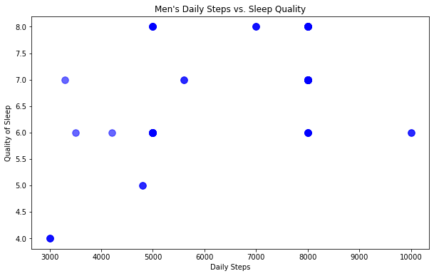

```python
#plot the men's daily steps vs quality of sleep
plt.scatter(ds_men,qs_men, alpha=0.6, color='blue', s=90)
plt.title("Men's Daily Steps vs. Sleep Quality")
plt.xlabel("Daily Steps")
plt.ylabel("Quality of Sleep")
```

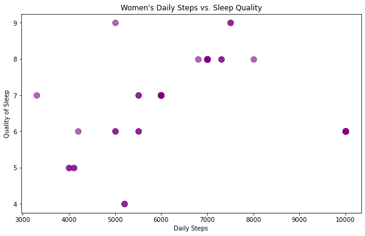

```python
#plot the women's daily steps vs quality of sleep
plt.scatter(ds_women,qs_women, alpha=0.6, color='purple', s=90)
plt.title("Women's Daily Steps vs. Sleep Quality")
plt.xlabel("Daily Steps")
plt.ylabel("Quality of Sleep")
```

For the next factor, I focused on the stress level. I used indexing to get just the stress level and plotted that against the quality of sleep. This is an overall plot for both men and women.

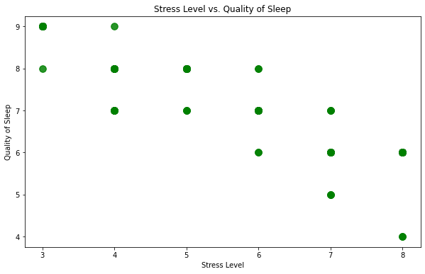

```python
#index data to get stress level
stress_level = sleep_data['Stress Level']
stress_level


quality_sleep = sleep_data['Quality of Sleep']
quality_sleep

plt.scatter(stress_level, quality_sleep, alpha=0.6, color='green', s=90)

plt.title("Stress Level vs. Quality of Sleep")
plt.xlabel("Stress Level")
plt.ylabel("Quality of Sleep")
plt.rcParams['figure.figsize'] = [10, 6]
```

```python
# get stress level for only men and convert to list
sl_men_list = males['Stress Level'].tolist()
# get stress level for only women and convert to list
sl_women_list = females['Stress Level'].tolist()
# get quality of sleep for both men and women and convert to a list
qs_men_list = males['Quality of Sleep'].tolist()
qs_women_list = females['Quality of Sleep'].tolist()
```

```python
#convert list to numpy list for stress level
sl_men = np.array(sl_men_list, dtype=np.int32)
# use same quality of sleep numpy list
qs_men = np.array(qs_men_list, dtype=np.int32)

#convert stress level list to numpy list for women
sl_women = np.array(sl_women_list, dtype=np.int32)
# use same quality of sleep numpy list
qs_women_list = females['Quality of Sleep'].tolist()
```

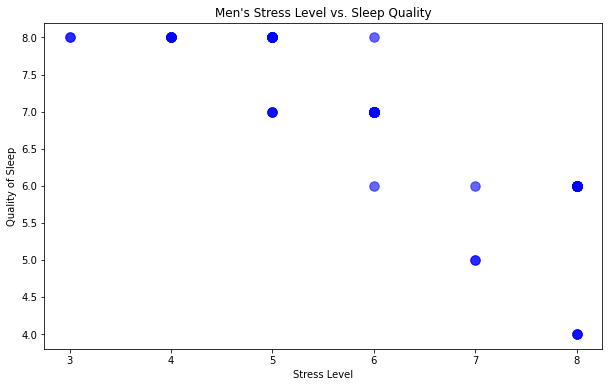

```python
#plot the men's stress level vs quality of sleep
plt.scatter(sl_men,qs_men, alpha=0.6, color='blue', s=90)
plt.title("Men's Stress Level vs. Sleep Quality")
plt.xlabel("Stress Level")
plt.ylabel("Quality of Sleep")
```

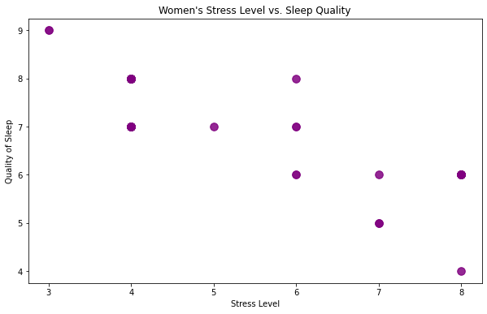

```python
#plot the women's daily steps vs quality of sleep
plt.scatter(sl_women,qs_women, alpha=0.6, color='purple', s=90)
plt.title("Women's Stress Level vs. Sleep Quality")
plt.xlabel("Stress Level")
plt.ylabel("Quality of Sleep")
```

For this section, I was curious to see which jobs had an positive/negative impact on the quality of sleep. By filtering the dataset by occupation, I was able to specify the type of job within that category. I wanted to make sure there were an equal set of data points for each job, hence I set it to the first 20 values.

```python
#index to just get the data for each of the three jobs (40 count)
accountants = sleep_data[sleep_data['Occupation'] == 'Accountant'][:20]
print(accountants)

doctors = sleep_data[sleep_data['Occupation'] == 'Doctor'][:20]
print(doctors)

nurses = sleep_data[sleep_data['Occupation'] == 'Nurse'][:20]
print(nurses)
```

```
     Person ID  Gender  Age  Occupation  Sleep Duration  Quality of Sleep  \
66          67    Male   32  Accountant             7.2                 8
85          86  Female   35  Accountant             7.2                 8
94          95  Female   36  Accountant             7.2                 8
95          96  Female   36  Accountant             7.1                 8
96          97  Female   36  Accountant             7.2                 8
97          98  Female   36  Accountant             7.1                 8
110        111  Female   37  Accountant             7.2                 8
112        113  Female   37  Accountant             7.2                 8
114        115  Female   37  Accountant             7.2                 8
115        116  Female   37  Accountant             7.2                 8
116        117  Female   37  Accountant             7.2                 8
117        118  Female   37  Accountant             7.2                 8
118        119  Female   37  Accountant             7.2                 8
119        120  Female   37  Accountant             7.2                 8
```

[output cut: 180 more lines]

In order to plot the correlation between occupation and sleep quality, I had to get an average of each occupation's quality of sleep.

```python
# get the average quality of sleep for each job
avg_acc = accountants['Quality of Sleep'].mean()
avg_doc = doctors['Quality of Sleep'].mean()
avg_nurse = nurses['Quality of Sleep'].mean()

print(avg_acc)
print(avg_doc)
print(avg_nurse)

# put all averages into a list (y variable)
average_sleep = [avg_acc,avg_doc,avg_nurse]
# put the three occupations chosen into a list
occ = ['Accountant', 'Doctor', 'Nurse']
```

```
8.0
6.6
6.0
```

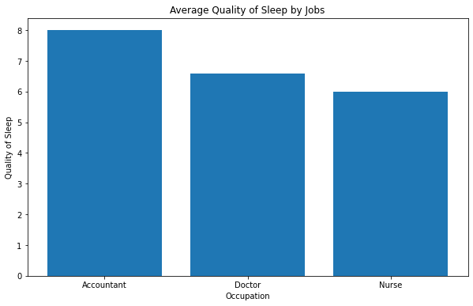

```python
plt.bar(occ,average_sleep)
plt.title('Average Quality of Sleep by Jobs')
plt.xlabel('Occupation')
plt.ylabel('Quality of Sleep')
```

```python
#index to just get the data for each of the three jobs (40 count)
engineers = sleep_data[sleep_data['Occupation'] == 'Engineer'][:15]
print(engineers)

teachers = sleep_data[sleep_data['Occupation'] == 'Teacher'][:15]
print(teachers)

sales = sleep_data[sleep_data['Occupation'] == 'Salesperson'][:15]
print(sales)
```

```
     Person ID Gender  Age Occupation  Sleep Duration  Quality of Sleep  \
50          51   Male   32   Engineer             7.5                 8
51          52   Male   32   Engineer             7.5                 8
86          87   Male   35   Engineer             7.2                 8
87          88   Male   35   Engineer             7.2                 8
88          89   Male   35   Engineer             7.3                 8
89          90   Male   35   Engineer             7.3                 8
90          91   Male   35   Engineer             7.3                 8
91          92   Male   35   Engineer             7.3                 8
107        108   Male   37   Engineer             7.8                 8
108        109   Male   37   Engineer             7.8                 8
147        148   Male   39   Engineer             6.5                 5
166        167   Male   41   Engineer             7.3                 8
201        202   Male   43   Engineer             7.8                 8
202        203   Male   43   Engineer             7.8                 8
```

[output cut: 135 more lines]

```python
# get the average quality of sleep for each job
avg_e = engineers['Quality of Sleep'].mean()
avg_t = teachers['Quality of Sleep'].mean()
avg_s = sales['Quality of Sleep'].mean()

print(avg_e)
print(avg_t)
print(avg_s)

# put all averages into a list (y variable)
average_sleep_ets = [avg_e,avg_t,avg_s]
# put the three occupations chosen into a list
occu = ['Engineer', 'Teacher', 'Salesperson']
```

```
7.666666666666667
6.933333333333334
6.0
```

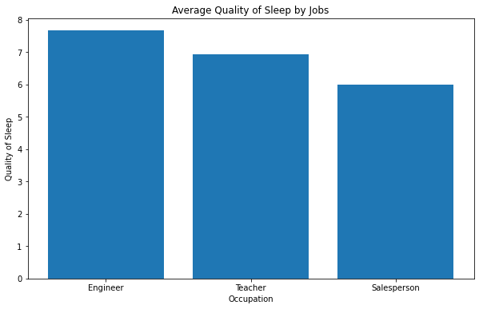

```python
plt.bar(occu,average_sleep_ets)
plt.title('Average Quality of Sleep by Jobs')
plt.xlabel('Occupation')
plt.ylabel('Quality of Sleep')
```

## Results

From the daily steps vs. quality of sleep plot shown above, there is a positive correlation from the amount of daily steps a person takes in a day to their quality of sleep on a scale from 1-10 (1 being the worst and 10 being the best). More specifically, both men and women also had the same positive correlation. From the stress level and quality of sleep plot, there is a clear negative correlation for both men and women. Lastly, for the average quality of sleep by jobs, I plotted 2 different graphs with three different jobs in each graph. It is found that accountants had the highest average of sleep quality, 8.0, while nurses had the lowest average with an average of 6.0. In the next graph, engineers were shown to have the highest average quality of sleep of 7.6 and the salesperson with the lowest average, 6.0.

## Discussion and Conclusion

This dataset provided key insights into the various factors that play a role in the quality of sleep an individual receives. The three factors that I explored in my project were daily steps vs. quality of sleep, stress level vs. quality of sleep, and the average quality of sleep for accountants, doctors, nurses, engineers, teachers, and salespeople. In the daily steps vs quality of sleep plot, there was a positive correlation, indicating that individuals who took more daily steps tend to have a better quality of sleep. For a man that had around 3,000 daily steps, they rated their quality of sleep as a 4. A man that had around 8000 steps, rated their quality of sleep as 8.0. This trend was consistent for both men and women showing that the more physical activity a person has, the better the quality of sleep is.

The stress level vs. quality of sleep plot depicted a clear negative correlation for both men and women. This aligns with previous research that suggests high stress levels can negatively impact sleep quality. These results confirm the significance of stress management in order to gain an increased quality of sleep.

To find which occupation tends to get a higher quality of sleep, I found that accountants and engineers, on average, get the highest quality of sleep while nurses and salespersons had the lowest. Engineers had an average of 7.6 in their quality of sleep, while nurses had an average rating of 6.0. This makes sense as nurses also tend to work long hours in a single day, and a lot of their work includes walking on the hospital floor, getting to patient’s rooms, etc. This may lead to less amounts of sleep, thus poor quality of sleep.

Some of the obstacles I ran into were how I was going to get an equal amount of data values for both men and women, as well as the different occupations. There is a different sample size for the varying occupations, so I wanted to make sure that I filter out the data to get the same sample size for each occupation. Something I would do differently next time is to explore how different age groups and bmi levels impact the relationship between daily steps/stress levels and the quality of sleep. Overall, this project allowed me to get a better understanding of how to mask/clean data, look for trends, and plot these relationships. I was able to confirm my hypothesis that higher daily steps and low stress levels lead to a higher quality of sleep.

## References

ChrisChris 29.4k2828 gold badges8787 silver badges160160 bronze badges, et al. “How to Make Inline Plots in Jupyter Notebook Larger?” Stack Overflow, 1 May 1962, stackoverflow.com/questions/36367986/how-to-make-inline-plots-in-jupyter-notebook-larger.

Kimura, Noriyuki, et al. “Association between Objectively Measured Walking Steps and Sleep in Community-Dwelling Older Adults: A Prospective Cohort Study.” PloS One, U.S. National Library of Medicine, 14 Dec. 2020, www.ncbi.nlm.nih.gov/pmc/articles/PMC7735606/.

Stories, Kamut. “‘The Three Steps to a Perfect Sleep.’” Medium, Medium, 12 Apr. 2021, matias-kortesniemibusiness.medium.com/the-three-steps-to-a-perfect-sleep-b4b76417debb.